# The magic of bootstrapping

Steve Cunningham

2018-03-13

# Introduction

## What are we doing?

- We all know how to calculate the mean and variance of a dataset.
- We also know that these are just point estimates - they can change if we get a new sample of data tomorrow.
- Often we want to be able to include a measure of uncertainty around our estimates.
- Sometimes this is easy, sometimes it’s not.

## What are we doing?

- Calculating the variance of an estimate usually relies on specific closed-form expressions.
- Sometimes these expressions are difficult to calculate, require strong assumptions, or simply don’t exist.
- Often, we can’t be sure about the underlying distribution of our data.
- Bootstrapping is an approach to inference that doesn’t require assumptions about the underlying data-generating process.

# Background

## Two useful concepts

**Law of Large Numbers**

- As the number of observations grows, the mean of those observations tends towards the expected value of the underlying distribution.

**Central Limit Theorem**

- If we repeatedly sample the mean of a distribution, the means of those samples will be normally distributed.

Both of these apply *regardless of the underlying distribution*.

## Law of Large Numbers

In code:

```r
# Let's test the LLN on a normal distribution

# set random seed so the graph looks the same each time
set.seed(123)

# Generate 10k observations of a normal variable
x <- rnorm(10000)

# Calculate the cumulative mean of x
lln <- data_frame(x) %>%
  mutate(
    n = 1:n()                # an index to track n
    , s = cumsum(x)          # cumulative sum of x
    , avg = s / n            # cumulative mean of x
  )
```

## Law of Large Numbers

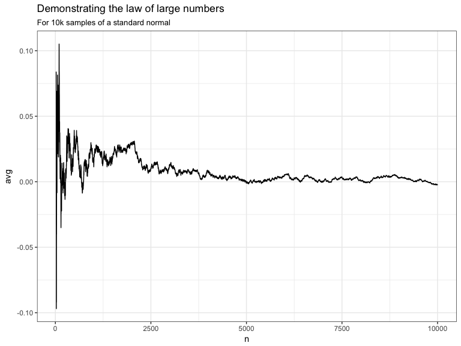

## Central Limit Theorem

In code:

```r
# Let's test the CLT on a binomial distribution

# set random seed so the graph looks the same each time
set.seed(123)

# Set up some parameters

means <- c()    # vector to store the means
n <- 1000       # binomial will have n trials
p <- 0.05       # prob of success
s <- 10000      # we will do this 10k times

# hacky for-loop to calculate the means
for (i in 1:s) {
  x <- rbinom(n = n, size = 100, prob = p)
  mu <- mean(x)
  means <- c(means, mu)
}
```

## Central Limit Theorem

Create a data frame with a sample of observations:

```r
observations <- data_frame(
  x = rbinom(n = n, size = 100, prob = p)
)
```

And one with the means we calculated:

```r
means <- data_frame(x = means)
```

## Central Limit Theorem

[figure not shown]

## Central Limit Theorem

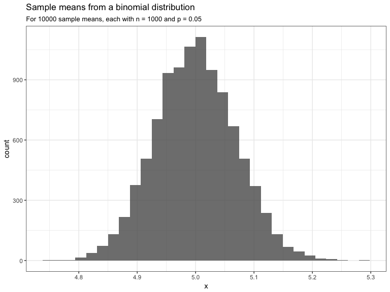

## Why is this useful?

If we have enough samples of our data, then for any distribution we can:

- Estimate the expected value
- Estimate the distribution of the expected value
- Even if we don’t know anything about the distribution

What if we don’t have thousands of samples? What if we only have one?

- Bootstrap!

# Bootstrap

## The bootstrap principle

- In an ideal world, we would do statistics by repeatedly sampling the population and doing inference based on those samples (the **sample distribution**).
- In the real (crappier) world, we only get one sample.
- This sample is the **best approximation** we have to the population.
- So if we repeatedly sample our observations instead, that’s the best approximation we have to our ideal world approach.
- Bootstrapping is a way to approximate the sampling distribution, which is a way to approximate the actual distribution.

## Bootstrap 101

Doing the bootstrap in 6 easy steps:

1. Pick a function $T$ that you’d like to estimate.
2. Sample $n$ observations from your dataset with replacement.
3. Calculate $T(X)$ for that sample, call it $T^*$
4. Do this $B$ times.
5. Take the mean of all your $T^*$s, called $\bar{T}^*$
6. Calculate the variance of $\bar{T}^*$ as:

$$\mathbb{V}_T = \frac{1}{B} \sum_{b=1}^B \left( {T_{b}}^{*} - \bar{T}^* \right)^2$$

## Example

Very simple approach:

```r
# Let's bootstrap the mean of a uniform(0,1) variable
B = 10000           # we'll do this 10000 times
n = 100             # with n = 100

x <- runif(n)       # generate n observations
boot <- c()         # save our mean here

for (i in 1:B){     # do it!
  x_star <- sample(x, n, replace = TRUE)
  boot[i] <- mean(x_star)
}
```

## Example

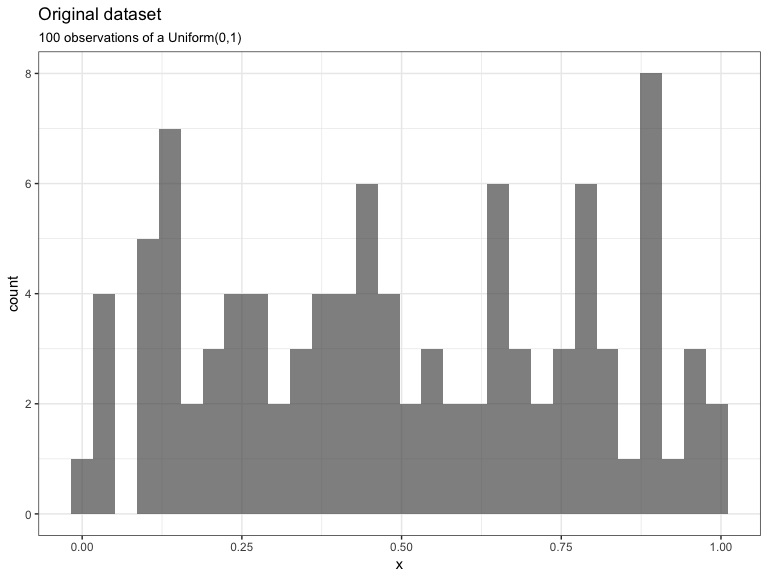

## Example

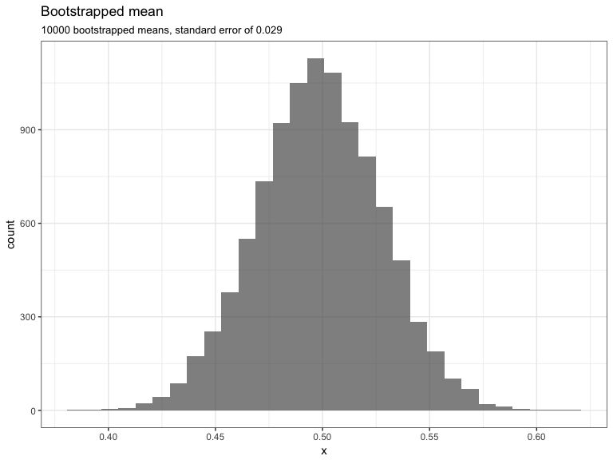

## Tidy bootstrapping

```r
library(modelr)
```

For-loops are great, but can get tricky if we want to do anything other than simple statistics.

The tidyverse has some cool tools for generating and manipulating samples on the fly.

```r
B <- 10000    # keep it small for now

# bootstrap some samples
samples <- data_frame(x) %>%
  # get B samples
  modelr::bootstrap(B)
```

## Tidy bootstrapping

Gives us a set of samples (strap) each with an id:

```r
samples %>% head()
```

```
## # A tibble: 6 x 2
##   strap          .id
##   <list>         <chr>
## 1 <S3: resample> 00001
## 2 <S3: resample> 00002
## 3 <S3: resample> 00003
## 4 <S3: resample> 00004
## 5 <S3: resample> 00005
## 6 <S3: resample> 00006
```

## Tidy bootstrapping

We can view the data like so:

```r
samples %>%

  # ugly
  unnest(strap %>% map(as.data.frame)) %>%

  head()
```

```
## # A tibble: 6 x 2
##   .id       x
##   <chr> <dbl>
## 1 00001 0.289
## 2 00001 0.352
## 3 00001 0.143
## 4 00001 0.886
## 5 00001 0.320
## 6 00001 0.940
```

## Tidy bootstrapping

Doing it on the fly:

```r
samples %>%

  # convert back to data
  unnest(strap %>% map(as.data.frame)) %>%

  # calculate mean of each sample
  group_by(.id) %>%
  summarize(avg = mean(x)) %>%

  # plot!
  ggplot(aes(avg)) +
  geom_histogram(alpha = .7)
```

## Tidy bootstrapping

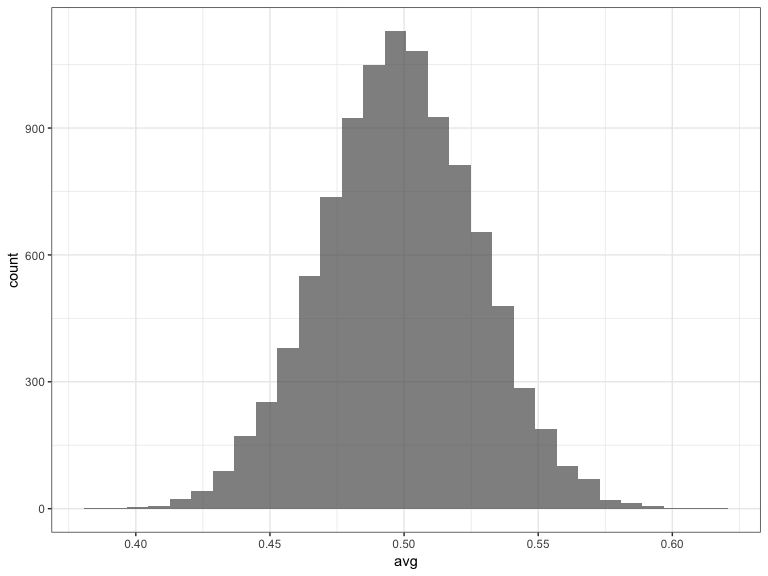

## Let’s do more

Say we’re bored of estimating means, let’s try bootstrap the variance:

```r
samples %>%

  # convert back to data
  unnest(strap %>% map(as.data.frame)) %>%

  # calculate variance of each sample
  group_by(.id) %>%
  summarize(variance = var(x)) %>%

  # plot!
  ggplot(aes(variance)) +
  geom_histogram(alpha = .7)
```

## Let’s do more

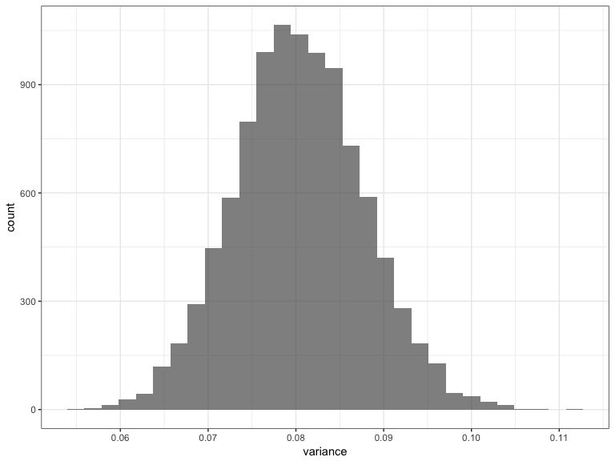

## Bootstrap usecases

1. I want to state the mean of some observations, and also include a measure of certainty.
2. I want to test a hypothesis about two groups, but I forgot how to do it.
3. I want to estimate the correlation between two variables, including an estimate of confidence.
4. I want to make a model more robust to overfitting.

¯\_(ツ)_/¯

## Confidence intervals

- We want to be able to give an interval which we are **reasonably confident** contains the true value of the statistic we’re estimating.
- Often we want to be able to say we’re **95% sure** that this interval contains the true value.
- That is, 95% of the time we construct this interval, it will contain the true value.
- We can find this interval by taking the middle 95% of our bootstrapped distribution.

## Confidence intervals

This technique is known as the **bootstrap percentile** method.

```r
vars <- samples %>%
  unnest(strap %>% map(as.data.frame)) %>%
  group_by(.id) %>%
  summarize(variance = var(x))

# get the quantiles
ci <- quantile(vars$variance, c(.025, .975))
```

```r
# plot!
vars %>%
  ggplot(aes(variance)) +
  geom_histogram(alpha = .7) +
  geom_vline(xintercept = ci, linetype = "dashed")
```

## Confidence intervals

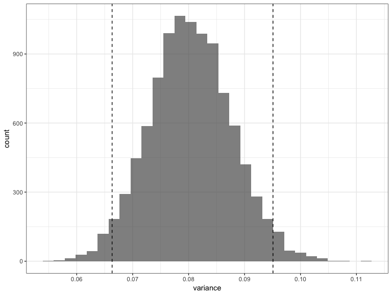

## Bootstrap a difference

- Up until now we’ve just modelled a single variable.
- Now we want to look at multiple variables.
- We can still model this as single variable problem.
- In this case, the single variable is the **difference** between two samples.

## Bootstrap a difference

Summarizing the approach:

- Get a bootstrap sample of variable A
- Get a bootstrap sample of variable B
- Calculate the difference in the means of the two samples
- Do this $B$ times
- Calculate the mean and confidence interval for the differences

## Bootstrap a difference

- Let’s create some sample data.

```r
# Two campaigns, each 10k emails, each either converted (1) or didn't
n <- 1000
mail_A <- rbinom(n, size=1, prob = 0.05)      # A converts with 5% probability
mail_B <- rbinom(n, size=1, prob = 0.075)     # B converts with 7.5% probability

means_A <- data_frame(x = mail_A) %>%         # Bootstrap the rates
  modelr::bootstrap(B) %>%
  unnest(strap %>% map(as.data.frame)) %>%
  group_by(.id) %>%
  summarize(a = mean(x))

means_B <- data_frame(x = mail_B) %>%
  modelr::bootstrap(B) %>%
  unnest(strap %>% map(as.data.frame)) %>%
  group_by(.id) %>%
  summarize(b = mean(x))

means <- inner_join(means_A, means_B) %>%
    mutate(delta = b - a)                     # calculate the diffs
```

## Bootstrap a difference

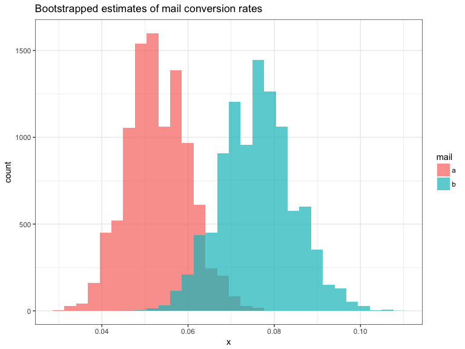

## Bootstrap a difference

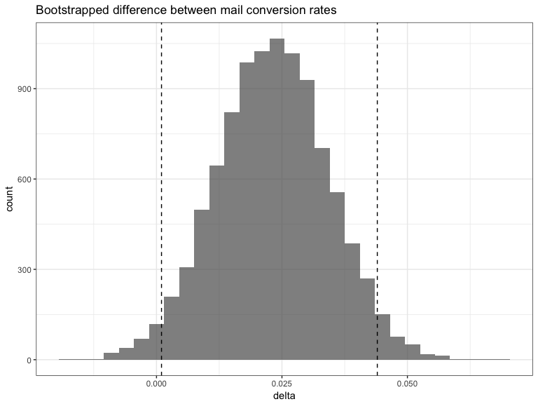

## Bootstrap a difference

- Note that this means we are **95% confident** that this interval does not include zero.
- That is, we’re 95% confident that the difference between the two campaigns is greater than zero.
- This is a hypothesis test!

## Comparison with a t-test

- Unlike a standard t-test, the bootstrap difference makes no assumptions about equal variance or sample size between groups.
- For small samples, (n < 100) t-tests with correct assumptions are still more accurate.

## Bootstrap correlation

Let’s bootstrap the correlation between two variables.

```r
# generate x and y so that they are correlated
x <- rnorm(1000)
y <- x + rnorm(1000)
```

## Bootstrap correlation

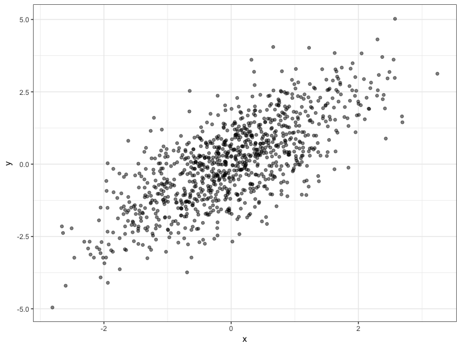

## Bootstrap correlation

The procedure is slightly different from last time:

- Previously we sampled A and B independently.
- This time we want to sample the pairwise distribution of x and y.

## Bootstrap correlation

In code:

```r
data <- data_frame(x, y)

correlations <- data %>%
  modelr::bootstrap(B) %>%
  unnest(strap %>% map(as.data.frame)) %>%
  group_by(.id) %>%
  summarize(correlation = cor(x, y))
```

## Bootstrap correlation

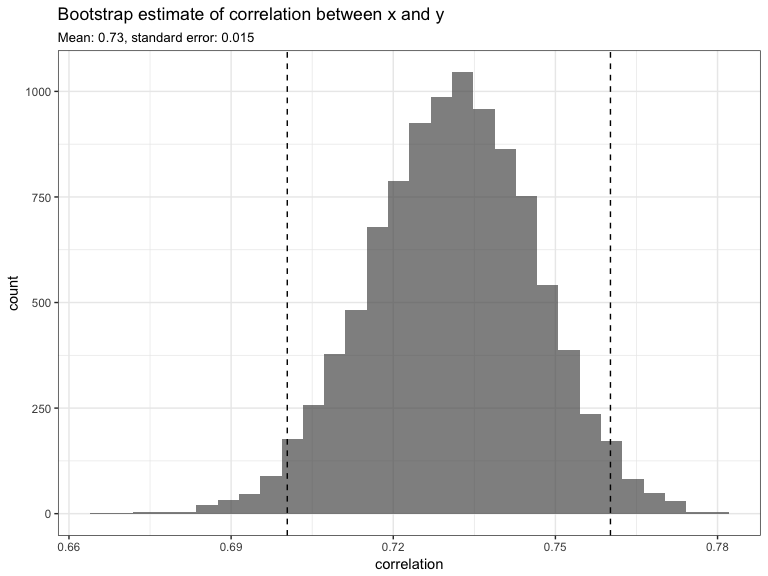

## Bootstrapping a model

- Finally, let’s bootstrap an entire linear model.
- R has a bunch of built-in datasets, we’re going to use ‘mtcars’:

```r
mtcars %>% head()
```

```
##                    mpg cyl disp  hp drat    wt  qsec vs am gear carb
## Mazda RX4         21.0   6  160 110 3.90 2.620 16.46  0  1    4    4
## Mazda RX4 Wag     21.0   6  160 110 3.90 2.875 17.02  0  1    4    4
## Datsun 710        22.8   4  108  93 3.85 2.320 18.61  1  1    4    1
## Hornet 4 Drive    21.4   6  258 110 3.08 3.215 19.44  1  0    3    1
## Hornet Sportabout 18.7   8  360 175 3.15 3.440 17.02  0  0    3    2
## Valiant           18.1   6  225 105 2.76 3.460 20.22  1  0    3    1
```

## Bootstrapping a model

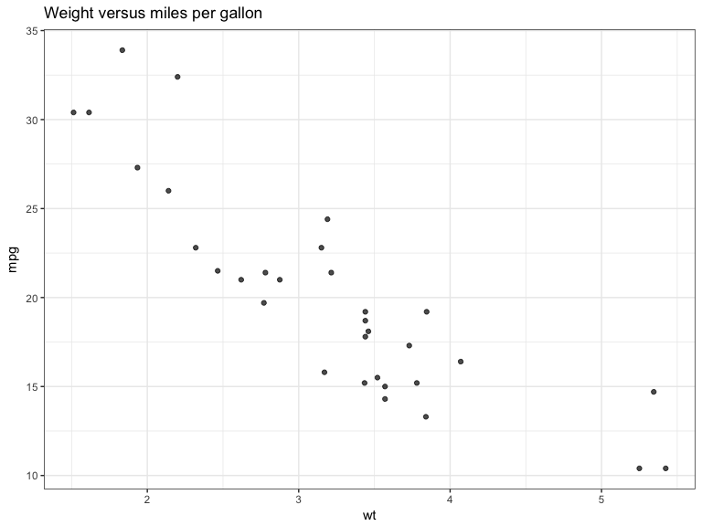

## Bootstrapping a model

Bootstrapping the parameters:

```r
# bootstrap the params
params <- mtcars %>%

  # get 1000 samples
  bootstrap(1000) %>%

  # group by each sample individually
  group_by(.id) %>%

  # for each sample, fit a model
  do(model = lm(mpg ~ wt, data=as.data.frame(.$strap))) %>%

  # tidy up the model params
  broom::tidy(model)
```

## Bootstrapping a model

```
## # A tibble: 6 x 6
## # Groups: .id [3]
##   .id   term        estimate std.error statistic                p.value
##   <chr> <chr>          <dbl>     <dbl>     <dbl>                  <dbl>
## 1 0001  (Intercept)    37.0      2.26      16.4  0.000000000000000164
## 2 0001  wt            - 5.26     0.643    - 8.18 0.00000000395
## 3 0002  (Intercept)    37.8      2.03      18.6  0.00000000000000000498
## 4 0002  wt            - 5.62     0.639    - 8.80 0.000000000831
## 5 0003  (Intercept)    38.7      2.19      17.6  0.0000000000000000220
## 6 0003  wt            - 5.90     0.669    - 8.81 0.000000000798
```

## Bootstrapping a model

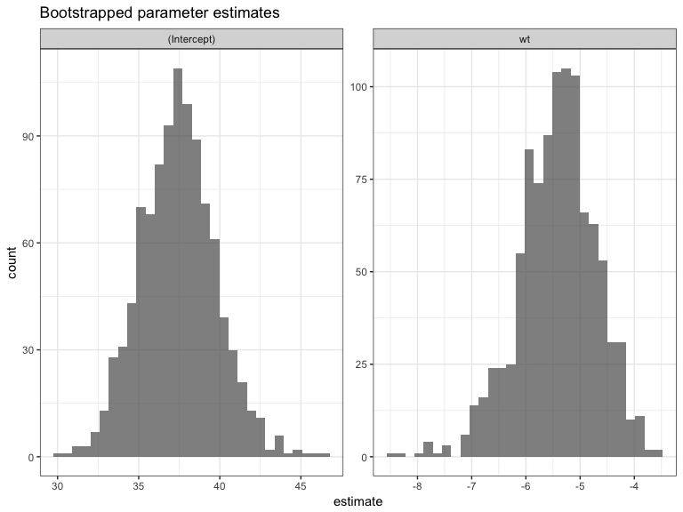

## Bootstrapping a model

```r
# bootstrap the fits
fits <- mtcars %>%

  # get 100 samples (makes plotting nicer)
  modelr::bootstrap(100) %>%

  # group by each sample individually
  group_by(.id) %>%

  # for each sample, fit a model
  do(model = lm(mpg ~ wt, data=as.data.frame(.$strap))) %>%

  # augment original data with fitted values
  broom::augment(model)
```

## Bootstrapping a model

```
## # A tibble: 6 x 11
## # Groups: .id [1]
##   .id   .row…   mpg    wt .fit… .se.…  .resid   .hat .sig… .cooksd .std.r…
##   <chr> <chr> <dbl> <dbl> <dbl> <dbl>   <dbl>  <dbl> <dbl>   <dbl>   <dbl>
## 1 001   Linc…  10.4  5.42  7.81 1.20   2.59   0.236   2.44 2.24e⁻¹  1.21
## 2 001   Merc…  19.2  3.44 18.1  0.438  1.07   0.0317  2.50 3.21e⁻³  0.443
## 3 001   Vali…  18.1  3.46 18.0  0.437  0.0774 0.0315  2.50 1.66e⁻⁵  0.0319
## 4 001   Cadi…  10.4  5.25  8.71 1.10   1.69   0.200   2.48 7.35e⁻²  0.767
## 5 001   Merc…  15.2  3.78 16.4  0.460 -1.16   0.0349  2.50 4.14e⁻³ -0.479
## 6 001   Pont…  19.2  3.84 16.0  0.474  3.18   0.0370  2.43 3.33e⁻²  1.32
```

## Bootstrapping a model

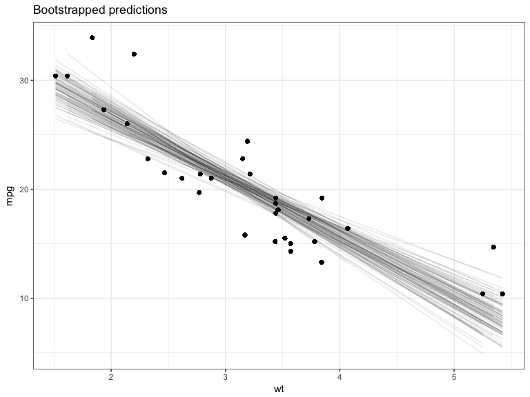

## Bootstrapping a model

- The graph above highlights the uncertainty around picking a model based on one sample of the data.
- We can also use it to generate confidence intervals around parameter estimates.
- Building a model based on bootstrap samples is also a way to avoid overfitting (known as bootstrap aggregating or ‘bagging’).

## Takeaways

- Bootstrapping is a robust solution to many types of inference problem.
- It can be used for simple problems where you need an approximate answer quickly.
- It can be used for more complicated problems where no closed-form solution exists.
- The bigger your initial sample size, the better it works.

## Caveats

- Bootstrapping is not a solution to small sample problems.
- Can still under-perform more specific tests at n < 100 (for normally distributed data) or n < 5000 (for long-tail distributions).
- Some remedies, see next slide.

## Further reading

- Wasserman, *All of Statistics*, chapters 7 and 8
- Efron, *Bootstrap Methods: Another Look at the Jackknife*
  - [link](https://projecteuclid.org/euclid.aos/1176344552)
- Tim Hesterberg, *What Teachers Should Know About the Bootstrap*
  - [short version](https://www.tandfonline.com/doi/pdf/10.1080/00031305.2015.1089789)
  - [long version](https://arxiv.org/abs/1411.5279)
- Stack Exchange:
  - [Can bootstrap be seen as a “cure” for the small sample size?](https://stats.stackexchange.com/q/112147)
  - [Why would I want to bootstrap when computing an independent sample t-test?](https://stats.stackexchange.com/q/128987)
  - [Explaining to laypeople why bootstrapping works](https://stats.stackexchange.com/q/26088)

# Thanks!